# PS5

Molly Thompson

2023-02-20

```r
library("readr")
library(dplyr)
library(tidyverse)
```

```r
library("ggplot2")


data <- read_delim("data/gapminder.csv.bz2")
```

## Load and check data

we have 13055 rows of data and 25 rows of columns

```r
data %>%
  sample(10)
```

```
## # A tibble: 13,055 × 10
##    agricul…¹ agric…²  time battl…³ ferti…⁴ acces…⁵ cerea…⁶ iso3  green…⁷ lifeE…⁸
##        <dbl>   <dbl> <dbl>   <dbl>   <dbl>   <dbl>   <dbl> <chr>   <dbl>   <dbl>
##  1        NA      NA  1960      NA      NA      NA      NA ABW        NA    65.7
##  2        20      NA  1961      NA      NA      NA      NA ABW        NA    66.1
##  3        20      NA  1962      NA      NA      NA      NA ABW        NA    66.4
##  4        20      NA  1963      NA      NA      NA      NA ABW        NA    66.8
##  5        20      NA  1964      NA      NA      NA      NA ABW        NA    67.1
##  6        20      NA  1965      NA      NA      NA      NA ABW        NA    67.4
##  7        20      NA  1966      NA      NA      NA      NA ABW        NA    67.8
##  8        20      NA  1967      NA      NA      NA      NA ABW        NA    68.1
##  9        20      NA  1968      NA      NA      NA      NA ABW        NA    68.4
## 10        20      NA  1969      NA      NA      NA      NA ABW        NA    68.8
## # … with 13,045 more rows, and abbreviated variable names ¹agriculturalLand,
## #   ²agricultureTractors, ³battleDeaths, ⁴fertilizerHa, ⁵accessElectricity,
## #   ⁶cerealProduction, ⁷greenhouseGases, ⁸lifeExpectancy
```

```r
countries_amount <- length(unique(data$name))
iso3_amount <- length(unique(data$iso3))
iso2_amount <- length(unique(data$iso2))
```

There are 250 countries in the data set, 253 3-letter country codes, and 249 2-letter country codes.

How many names are there for each iso-2 code and what are the duplicates

```r
data %>%
  group_by(iso2) %>%
  summarize(names = n_distinct(name))
```

```
## # A tibble: 249 × 2
##    iso2  names
##    <chr> <int>
##  1 AD        1
##  2 AE        1
##  3 AF        1
##  4 AG        1
##  5 AI        1
##  6 AL        1
##  7 AM        1
##  8 AO        1
##  9 AQ        1
## 10 AR        1
## # … with 239 more rows
```

```r
data %>%
  group_by(iso2, name) %>%
  summarise(n = n()) %>%
  filter(n > 1) %>%
  select(iso2, name)
```

```
## # A tibble: 214 × 2
## # Groups:   iso2 [213]
##    iso2  name
##    <chr> <chr>
##  1 AD    Andorra
##  2 AE    United Arab Emirates
##  3 AF    Afghanistan
##  4 AG    Antigua and Barbuda
##  5 AL    Albania
##  6 AM    Armenia
##  7 AO    Angola
##  8 AR    Argentina
##  9 AS    American Samoa
## 10 AT    Austria
## # … with 204 more rows
```

How many names are there for each iso-3 code and what are the duplicates

```r
data %>%
  group_by(iso3) %>%
  summarize(names = n_distinct(name))
```

```
## # A tibble: 253 × 2
##    iso3  names
##    <chr> <int>
##  1 ABW       1
##  2 AFG       1
##  3 AGO       1
##  4 AIA       1
##  5 ALA       1
##  6 ALB       1
##  7 AND       1
##  8 ARE       1
##  9 ARG       1
## 10 ARM       1
## # … with 243 more rows
```

```r
data %>%
  group_by(iso3, name) %>%
  summarise(n = n()) %>%
  filter(n > 1) %>%
  select(iso3, name)
```

```
## # A tibble: 217 × 2
## # Groups:   iso3 [217]
##    iso3  name
##    <chr> <chr>
##  1 ABW   Aruba
##  2 AFG   Afghanistan
##  3 AGO   Angola
##  4 ALB   Albania
##  5 AND   Andorra
##  6 ARE   United Arab Emirates
##  7 ARG   Argentina
##  8 ARM   Armenia
##  9 ASM   American Samoa
## 10 ATG   Antigua and Barbuda
## # … with 207 more rows
```

```r
min_year <- data %>%
  filter(!is.na(time)) %>%
  summarize(min_year = min(time))

max_year <- data %>%
  filter(!is.na(time)) %>%
  summarize(max_year = max(time))
```

The minimum year in this data is 1960 and the maximum year is 2019

## Total CO2 Emissions

```r
missing_co2 <- data %>%
  group_by(time) %>%
  summarize(missing_co2 = sum(is.na(co2)),
            missing_co2_pc = sum(is.na(co2_PC)))

most_missing <- missing_co2 %>%
  filter(missing_co2 + missing_co2_pc > 0) %>%
  arrange(desc(missing_co2 + missing_co2_pc)) %>%
  slice(1:5)

cat("The missing C02 emmisions per year are:")
```

```
## The missing C02 emmisions per year are:
```

```r
print(missing_co2)
```

```
## # A tibble: 61 × 3
##     time missing_co2 missing_co2_pc
##    <dbl>       <int>          <int>
##  1  1960          60             60
##  2  1961          60             60
##  3  1962          58             58
##  4  1963          57             57
##  5  1964          51             51
##  6  1965          51             51
##  7  1966          51             51
##  8  1967          51             51
##  9  1968          51             51
## 10  1969          51             51
## # … with 51 more rows
```

```r
cat("The years with the most missing data are:")
```

```
## The years with the most missing data are:
```

```r
print(most_missing)
```

```
## # A tibble: 5 × 3
##    time missing_co2 missing_co2_pc
##   <dbl>       <int>          <int>
## 1  2017         217            217
## 2  2018         217            217
## 3  2019         217            217
## 4  1960          60             60
## 5  1961          60             60
```

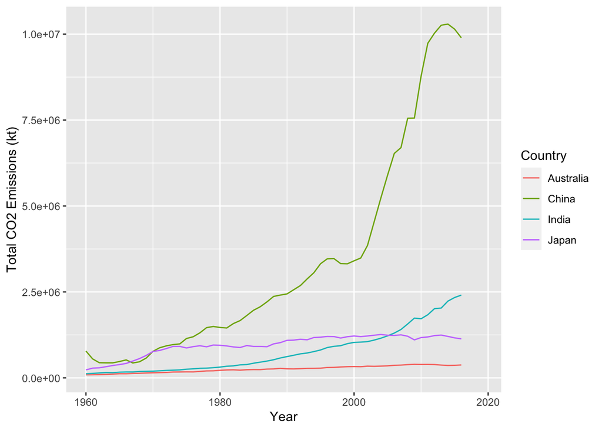

```r
countries <- c("U.S", "China", "India", "Japan", "Russia", "Australia")

co2_data <- data %>%
  filter(name %in% countries)

ggplot(co2_data, aes(x = time, y = co2, color = name)) +
  geom_line() +
  labs(x = "Year", y = "Total CO2 Emissions (kt)", color = "Country")
```

The data shows China as being the country contributing the most to CO2 emmisions. China contributed around the same amount of emissions as the other countries until around 1980 when it begain to rise and In 2000 it dramatically increased more. Among the lowest countries contributing to emissions is Australia.

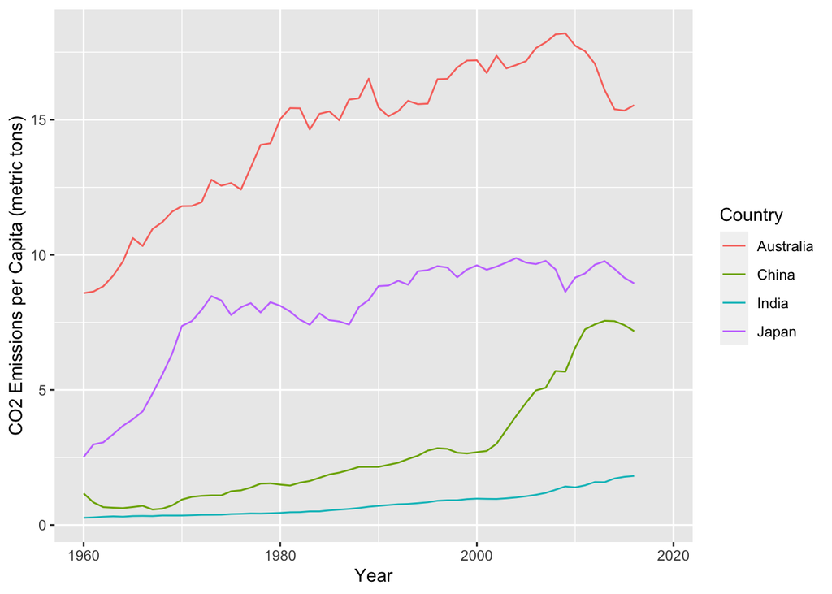

```r
co2_pc_data <- data %>% filter(name %in% countries)

ggplot(co2_pc_data, aes(x = time, y = co2_PC, color = name)) +
  geom_line() +
  labs(x = "Year", y = "CO2 Emissions per Capita (metric tons)", color = "Country")
```

This figure suggests that when considering the population of these countries, the data tells a different story of who is contributing the most in CO2 emissions per person in the country. Per capita, Australia is contributing more CO2 emmisions. This suggests that even though China has high CO2 emissions, it is because they have a higher population compared to the other countries in the graph.

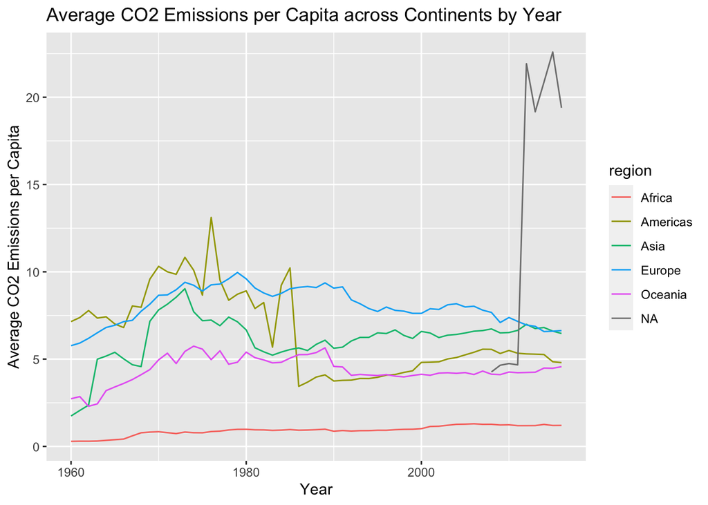

```r
data %>%
  filter(!is.na(co2_PC)) %>%
  group_by(region, time) %>%
  summarize(avg_co2_pc = mean(co2_PC)) %>%
  ggplot(aes(x = time, y = avg_co2_pc, color = region)) +
  geom_line() +
  xlab("Year") +
  ylab("Average CO2 Emissions per Capita") +
  ggtitle("Average CO2 Emissions per Capita across Continents by Year")
```

```r
avg_co2_pc <- data %>%
  filter(time %in% c(1960, 2016)) %>%
  group_by(region, time) %>%
  summarize(avg_co2_pc = mean(co2_PC, na.rm = TRUE))
```

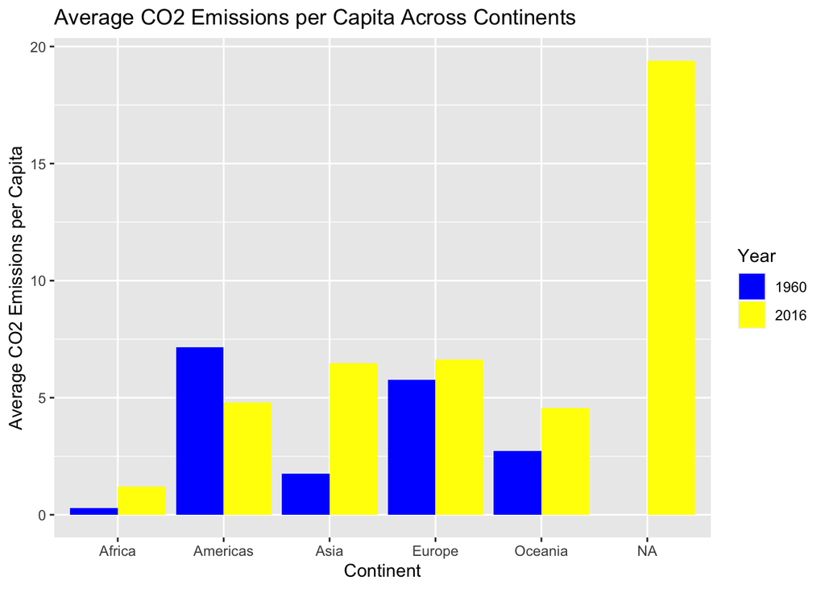

```r
ggplot(avg_co2_pc, aes(x = region, y = avg_co2_pc, fill = factor(time))) +
  geom_bar(stat = "identity", position = "dodge") +
  scale_fill_manual(values = c("blue", "yellow")) +
  labs(title = "Average CO2 Emissions per Capita Across Continents",
       x = "Continent",
       y = "Average CO2 Emissions per Capita",
       fill = "Year")
```

This barplot shows that all continents except for the Americas have increased their average C02 emmisions per Capita in some amount since 1960.

```r
data_2019 <- data %>%
  filter(time == 2019)

grouped_data <- data_2019 %>%
  group_by(region, name)

grouped_data <- grouped_data %>%
  mutate(co2_per_capita = co2_PC * totalPopulation / 1000000)

top_bottom_countries <- grouped_data %>%
  arrange(co2_per_capita) %>%
  group_by(region) %>%
  summarize(top3 = paste(name[1:3], collapse = ", "),
            bottom3 = paste(name[n() - 2:n()], collapse = ", "))

top_bottom_countries
```

```
## # A tibble: 6 × 3
##   region   top3                                       bottom3
##   <chr>    <chr>                                      <chr>
## 1 Africa   Angola, Burundi, Benin                     South Africa, Uganda, Tan…
## 2 Americas Aruba, Argentina, Antigua and Barbuda      Venezuela (Bolivarian Rep…
## 3 Asia     Afghanistan, United Arab Emirates, Armenia Uzbekistan, Turkey, Timor…
## 4 Europe   Albania, Andorra, Austria                  Slovenia, Slovakia, Serbi…
## 5 Oceania  American Samoa, Australia, Fiji            Tuvalu, Tonga, Solomon Is…
## 6 <NA>     NA, NA, NA                                 NA, NA
```

## GDP per capita

GDP per capita vs. Life expectancy by country in 1960

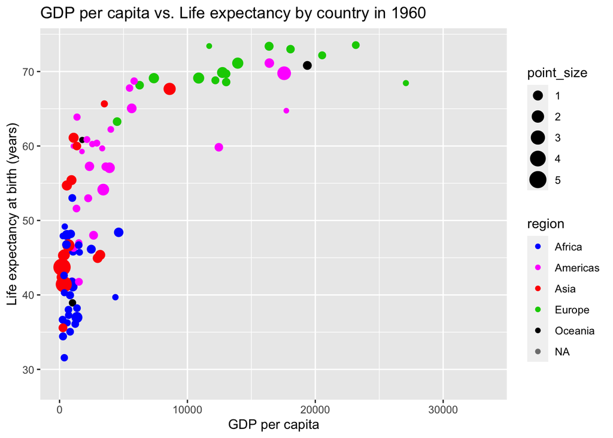

```r
data_1960 <- data %>%
  filter(time == 1960)

continent_colors <- data.frame(region = unique(data$region),
                               color = rainbow(length(unique(data$region))))
data_1960 <- data_1960 %>%
  left_join(continent_colors, by = "region")

data_1960 <- data_1960 %>%
  mutate(point_size = sqrt(totalPopulation) / 5000)

ggplot(data_1960, aes(x = GDP_PC, y = lifeExpectancy, color = region, size = point_size)) +
  geom_point() +
  scale_color_manual(values = continent_colors$color) +
  labs(x = "GDP per capita", y = "Life expectancy at birth (years)",
       title = "GDP per capita vs. Life expectancy by country in 1960")
```

According to the graph, there is a strong positive correlation between GDP per capita and life expectancy. The higher the GDP per capita, the higher the life expectancy. Europe ranks high on GDP and LE, while the Americas countries are more in the middle, and Asia and African countries rank lower on both.

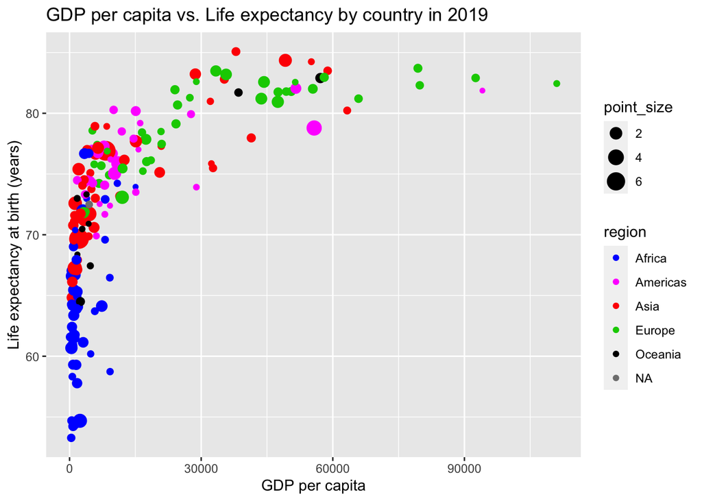

```r
data_2019 <- data %>% filter(time == 2019)

continent_colors <- data.frame(region = unique(data$region),
                               color = rainbow(length(unique(data$region))))

data_2019 <- data_2019 %>%
  left_join(continent_colors, by = "region")

data_2019 <- data_2019 %>%
  mutate(point_size = sqrt(totalPopulation) / 5000)

ggplot(data_2019, aes(x = GDP_PC, y = lifeExpectancy, color = region, size = point_size)) +
  geom_point() +
  scale_color_manual(values = continent_colors$color) +
  labs(x = "GDP per capita", y = "Life expectancy at birth (years)",
       title = "GDP per capita vs. Life expectancy by country in 2019")
```

Comparing these two plots of GDP per capita vs Life expectancy in 1960 and 2019 we can see that the population size for most countries has increased a lot. The life expectancy for most countries has also increased dramatically, most countries are in the range from 60-80 in 2019, compared to 1960 when the average LE range was around 40-65. This is most likely due to the increasing medical technology, increased vaccinations, and a reduction in harmful substance abuse like smoking.

```r
data_1960 <- data %>%
  filter(time == 1960 & !is.na(lifeExpectancy))

data_2019 <- data %>%
  filter(time == 2019 & !is.na(lifeExpectancy))

life_expectancy_1960 <- data_1960 %>%
  group_by(region) %>%
  summarize(avg_life_expectancy = mean(lifeExpectancy))

life_expectancy_2019 <- data_2019 %>%
  group_by(region) %>%
  summarize(avg_life_expectancy = mean(lifeExpectancy))

life_expectancy_1960
```

```
## # A tibble: 6 × 2
##   region   avg_life_expectancy
##   <chr>                  <dbl>
## 1 Africa                  41.5
## 2 Americas                58.6
## 3 Asia                    51.6
## 4 Europe                  68.3
## 5 Oceania                 56.4
## 6 <NA>                    70.7
```

```r
life_expectancy_2019
```

```
## # A tibble: 6 × 2
##   region   avg_life_expectancy
##   <chr>                  <dbl>
## 1 Africa                  64.1
## 2 Americas                75.8
## 3 Asia                    74.6
## 4 Europe                  79.4
## 5 Oceania                 73.5
## 6 <NA>                    77.8
```

The results match up with what can be seen on the figures above. Overall the average life expectancy has increased for all the continents from 1960 to 2019

```r
data_1960 <- data %>%
  filter(time == 1960 & !is.na(lifeExpectancy))
data_2019 <- data %>%
  filter(time == 2019 & !is.na(lifeExpectancy))

LE_growth <- data_1960 %>%
  left_join(data_2019, by = c("name", "region")) %>%
  mutate(growth = (lifeExpectancy.y - lifeExpectancy.x) / lifeExpectancy.x * 100) %>%
  select(region, growth) %>%
  group_by(region) %>%
  summarize(avg_growth = mean(growth, na.rm = TRUE)) %>%
  arrange(avg_growth)
LE_growth
```

```
## # A tibble: 6 × 2
##   region   avg_growth
##   <chr>         <dbl>
## 1 <NA>           9.97
## 2 Europe        16.2
## 3 Americas      30.9
## 4 Oceania       32.5
## 5 Asia          49.3
## 6 Africa        56.3
```

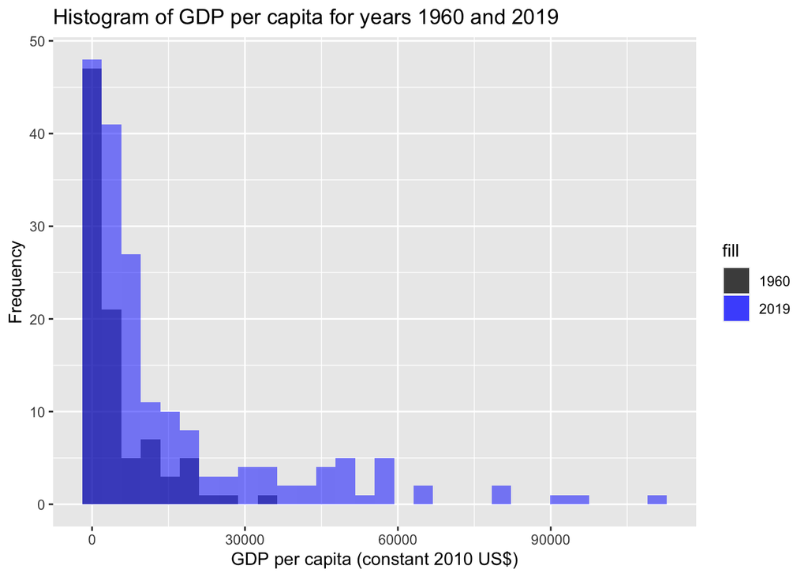

```r
# Subset data for the years 1960 and 2019
data_1960 <- subset(data, time == 1960 & !is.na(GDP_PC))
data_2019 <- subset(data, time == 2019 & !is.na(GDP_PC))

# Create histogram for GDP per capita in 1960 and 2019
ggplot() +
  geom_histogram(data = data_1960, aes(x = GDP_PC, fill = "1960"), alpha = 0.5, bins = 30) +
  geom_histogram(data = data_2019, aes(x = GDP_PC, fill = "2019"), alpha = 0.5, bins = 30) +
  scale_fill_manual(values = c("1960" = "black", "2019" = "blue")) +
  xlab("GDP per capita (constant 2010 US$)") +
  ylab("Frequency") +
  ggtitle("Histogram of GDP per capita for years 1960 and 2019")
```

```r
data_1960 <- subset(data, time == 1960 & !is.na(lifeExpectancy))
data_2019 <- subset(data, time == 2019 & !is.na(lifeExpectancy))

ordered_data1960 <- arrange(data_1960, desc(lifeExpectancy))
ordered_data2019 <- arrange(data_2019, desc(lifeExpectancy))

us_rank_1960 <- which(ordered_data1960$iso3 == "USA")
us_rank_2019 <- which(ordered_data2019$iso3 == "USA")

cat("The rank of the U.S in life expectancy in 1960 is:", us_rank_1960)
```

```
## The rank of the U.S in life expectancy in 1960 is: 18
```

```r
cat("The rank of the U.S in life expectancy in 2019 is:", us_rank_2019)
```

```
## The rank of the U.S in life expectancy in 2019 is: 47
```

```r
data1960 <- subset(data, time == 1960 & !is.na(lifeExpectancy))
data2019 <- subset(data, time == 2019 & !is.na(lifeExpectancy))

rank1960 <- rank(-data1960$lifeExpectancy, ties.method = "min")
rank2019 <- rank(-data2019$lifeExpectancy, ties.method = "min")

us1960_rank <- rank1960[data1960$name == "United States"]
us2019_rank <- rank2019[data2019$name == "United States"]

num_countries1960 <- length(data1960$name)
num_countries2019 <- length(data2019$name)

relative_rank1960 <- us1960_rank / num_countries1960
relative_rank2019 <- us2019_rank / num_countries2019

cat("The relative rank of the U.S. in 1960 is:", round(relative_rank1960 * 100, 2))
```

```
## The relative rank of the U.S. in 1960 is: NA
```

```r
cat("The relative rank of the U.S. in 2019 is:", round(relative_rank2019 * 100, 2))
```

```
## The relative rank of the U.S. in 2019 is: NA NA
```